# Week 3 HW

Tyler Jackson

4/20/2019

Week 3

# Part 1. Introduction to spatial data in *R*

First work through http://www.rspatial.org/spatial/ There is quite a lot of stuff, so go through it quickly. It is a reference.

Upload to Canvas this Rmarkdown file (and a pdf compilation) after adding R code and some text such to answer the questions below.

Consider answering by writing sentences that use inline R commands like this 5 + 5 = 10.

For this exercise **only use the sp and raster packages** (and indirectly, packages such as rgdal that raster may use in the background).

```r
#load libraries
library(sp)
library(raster)
library(rgdal)
```

```r
#can i use ggplot?
library(ggplot2)
library(ggthemes)

#data path
mypath <- "/Users/tyler/Dropbox/_200CN/labs/week3/data/"
```

*Questions*

## 1) Read in the data

**read the shapefile “galap.shp” (in galap.zip) into R to create a SpatialPolygonsDataFrame.**

```r
#unzip the zip file into the data path
unzip(file.path(mypath, "galap.zip") , exdir = file.path(mypath))

#read shapefile with readOGR
galap <- readOGR(file.path(mypath, "galap.shp"))
```

## 2) Class

**show the class of the object in R**

```r
#class
class(galap)
```

```
## [1] "SpatialPolygonsDataFrame"
## attr(,"package")
## [1] "sp"
```

The class of the object `galap` is SpatialPolygonsDataFrame.

## 3) Polygons

**how many polygons are there in this object?**

```r
#how many rows?
nrow(galap)
```

```
## [1] 30
```

There are 30 polygons in the object `galap`.

## 4) Variables

**how many variables are there in this object?**

```r
#how many columns
ncol(galap)
```

```
## [1] 12
```

There are 12 variables in the object `galap`.

## 5) Island Plots

**make a plot of the islands (their outlines)**

Plot

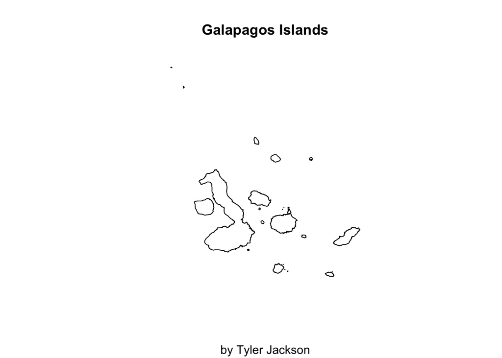

```r
#use plot
plot(galap)
title(main = "Galapagos Islands", sub = "by Tyler Jackson")
```

## 6) Scatter Plots

**make a scatter plot of the number of species as a function of the size of the island**

Check Data

```r
#get variable names to plot by looking at the data
head(galap)
```

```
##    NAME_0    NAME_1     NAME_2     Island ID species native    area
## 0 Ecuador Galápagos    Isabela    Tortuga 29      16      8    1.24
## 1 Ecuador Galápagos    Isabela    Isabela 16     347     89 4669.32
## 2 Ecuador Galápagos    Isabela Fernandina 12      93     35  634.29
## 3 Ecuador Galápagos Santa Cruz Las Plazas 21      12      9    0.23
## 4 Ecuador Galápagos Santa Cruz   Marchena 17      51     23  129.49
## 5 Ecuador Galápagos Santa Cruz      Pinta 19     104     37   59.56
##   elevation distNear distSC areaAdj
## 0       186      6.8   50.9   17.95
## 1      1707      0.7   28.1  634.49
## 2      1494      4.3   95.3 4669.32
## 3         0      0.5    0.6   25.09
## 4       343     29.1   85.9   59.56
## 5       777     29.1  119.6  129.49
```

```r
#we'll use species and areaAdj, let's make sure we can plot them
apply(as.data.frame(galap[,c(6,12)]), 2, typeof)
```

```
##  species  areaAdj
## "double" "double"
```

Plot

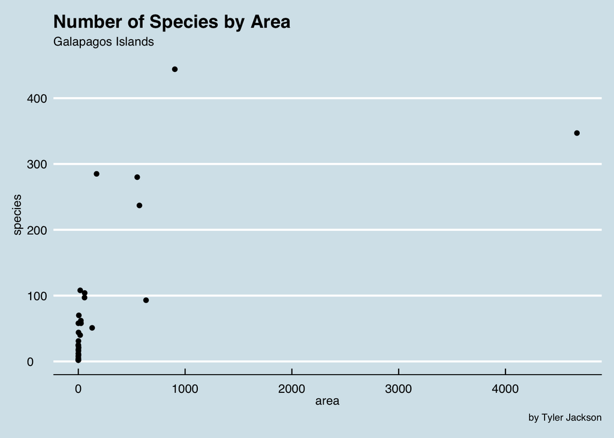

```r
#for some reason ggplot won't plot the SP dataframe so I passed it as a df
ggplot(as.data.frame(galap)) +
  geom_point(aes(area, species)) +
  labs(title = "Number of Species by Area", subtitle = "Galapagos Islands", caption = "by Tyler Jackson") +
  theme_economist()
```

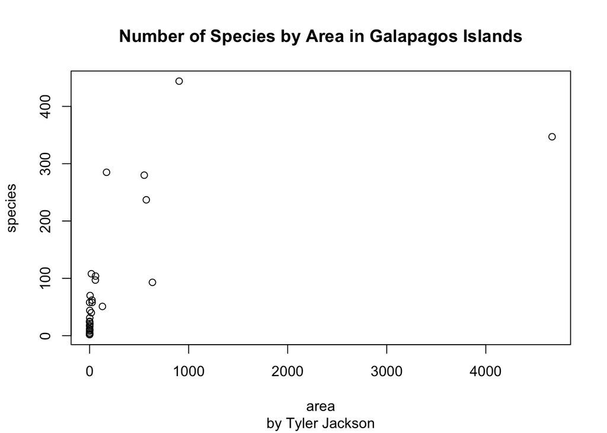

```r
#plot with the uglier plot
plot(species ~ area, galap)
title(main = "Number of Species by Area in Galapagos Islands", sub = "by Tyler Jackson")
```

## 7) Map variable?

**what quantity might you use to make a choropleth to represent the number of species on each island?**

> I would use at the very least a rate variable to represent the number of species on each island. So something like `species/area`. Using counts per island would not account for the different island sizes.

## 8) Chloropleth

**create that quantity as a new variable in the SpatialPolyonsDataFrame and plot it with “spplot”**

Calculate Rate

```r
#create species / area variable
galap$spRate <- (galap$species/galap$area)
```

Plot

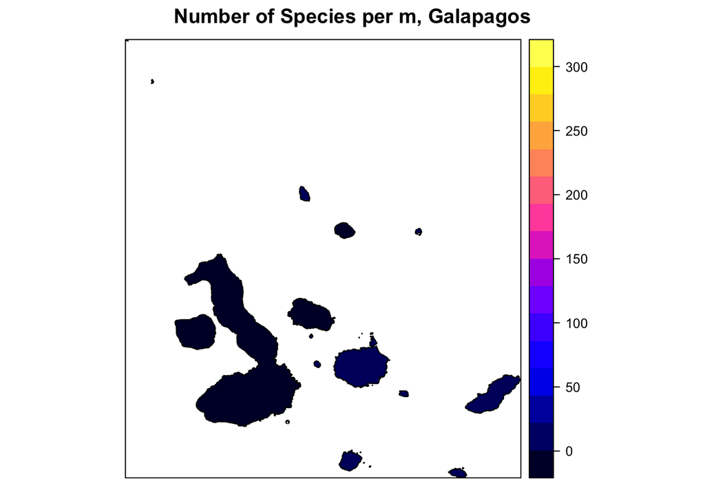

```r
#spplot does cholorpleths, second argument is the variable to plot
spplot(galap, "spRate", main = "Number of Species per m, Galapagos")
```

## 9) Saving the big island

**select the largest island and save it to a new shapefile**

```r
#which polygon is the biggest
which.max(galap$area) #row 2
```

```
## [1] 2
```

```r
#subset the island
big.island <- galap[2,]
```

```r
#save it using writeOGR
writeOGR(big.island, dsn = file.path(mypath),
         layer = "big.island", driver = "ESRI Shapefile",
         overwrite_layer = T)
```

## 10) Get elevation data

**download elevation data for Ecuador (use the “getData” in the raster package)**

Download Data

```r
#get data "alt = altitude"
ecuador <- getData('alt', country='ECU', download = TRUE)
```

Plot

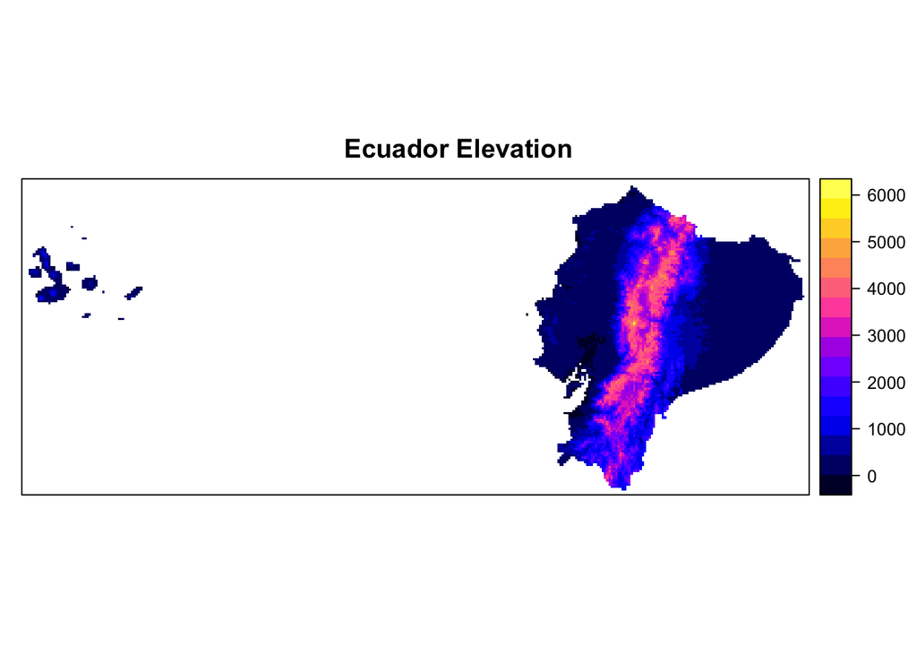

```r
#check it out
spplot(ecuador, main = "Ecuador Elevation")
```

## 11) Cropping

**use the crop function in the raster package and then map the elevation data (add the island outlines)**

Projections

```r
#check CRS for each object
crs(galap)
```

```
## CRS arguments:
##  +proj=utm +zone=15 +datum=WGS84 +units=m +no_defs +ellps=WGS84
## +towgs84=0,0,0
```

```r
crs(ecuador)
```

```
## CRS arguments:
##  +proj=longlat +datum=WGS84 +ellps=WGS84 +towgs84=0,0,0
```

```r
#reproject galap into the crs of ecuador
g.lonlat <- spTransform(galap, CRSobj = crs(ecuador))
```

Cropping

```r
#crop by the extent
g.crop <- crop(ecuador, extent(g.lonlat))
```

Plot

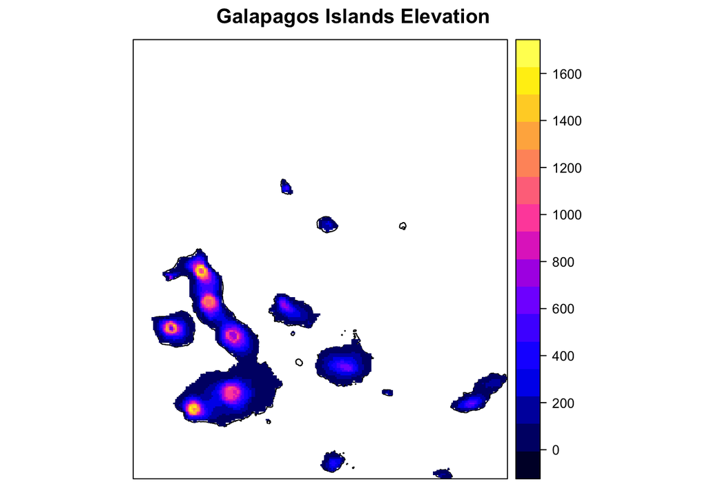

```r
#plot with outlines
spplot(g.crop, sp.layout = g.lonlat, main = "Galapagos Islands Elevation")
```

## 12) Contour maps

**create a contour map of elevation in Ecuador.**

Get boundary data

```r
#need to get poly lines for ecuador
ecu.poly <- getData('GADM', country='ECU', download = TRUE, level = 0)
```

Plot

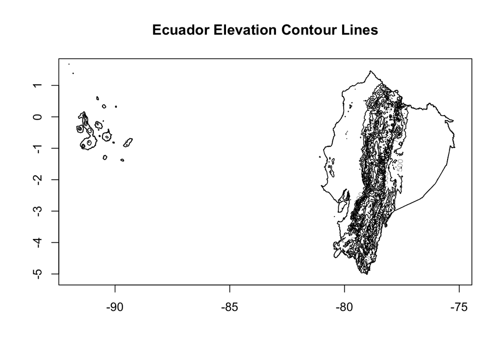

```r
#raster has a "contour" function
contour(ecuador, main = "Ecuador Elevation Contour Lines")
plot(ecu.poly, add = T)
```

# Part 2. Pattern and Process

Please read https://rspatial.org/rosu/Chapter4.html

**Questions**

## 1) Thought Exercise

**Use the examples provided above to write a script that follows the ‘thought exercise to fix ideas’ on page 98 of OSU.**

Use the basic equation (z = 2x + 3y + r), but instead of adding or subtracting 1 from each value, randomly add or subtract an integer (whole number) in the range 0–9 and prepare an isoline map of the result you obtain. You can get random numbers from a spreadsheet or from tables in most statistics textbooks.Take two digits at a time. If the first digit is less than 5 (0–4), add the next digit to your result; if it is 5 or more, subtract the next digit.

Raster

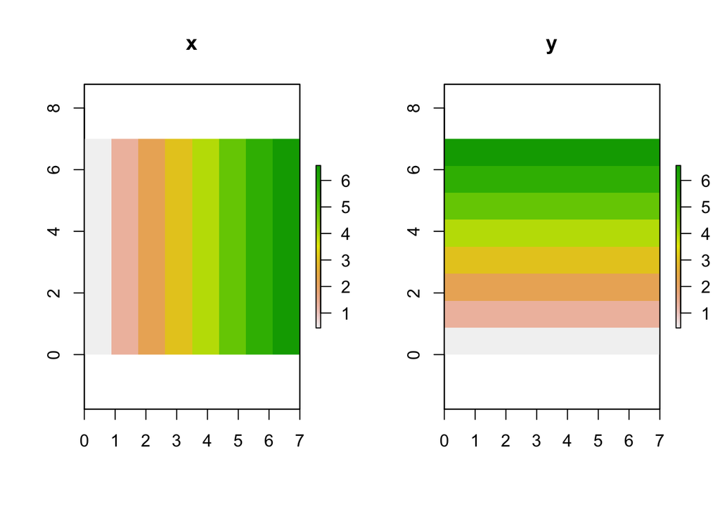

```r
#create a raster
r <- raster(xmn=0, xmx=7, ymn=0, ymx=7, ncol=8, nrow=8)

#get x and y raster for the equation
X <- init(r, 'x')
Y <- init(r, 'y')

#plot to make sure it worked
par(mfrow = c(1,2))
plot(X, main = 'x')
plot(Y, main = 'y')
```

```r
par(mfrow = c(1,1))
```

Random numbers

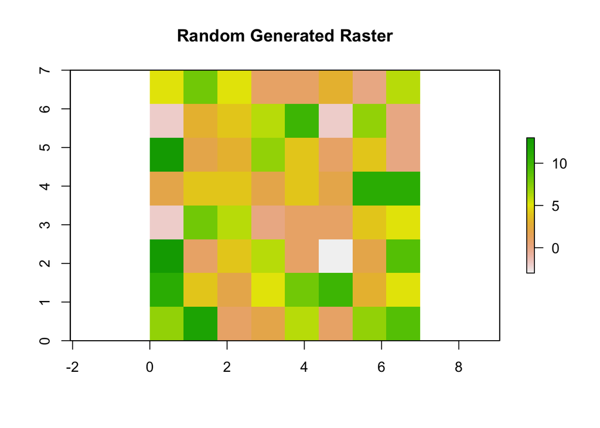

```r
#set seet to start in the same "random" place
set.seed(0)

#get random numbers for the matrix
#book asks for "2 digits at a time"
n <- round(runif(ncell(r), min = 0, max = 9))
m <- round(runif(ncell(r), min = 0, max = 9))

# book asks "If the first digit is less than 5, add the next digit to your result; if it is 5 or more, subtract the next digit"
# I have approxamated this using ifelse
s <- ifelse(n < 5, n + m, n - m)

#fill the raster with s
R <- setValues(r, s)

#looks random?
plot(R, main = "Random Generated Raster")
```

Plot the random contours

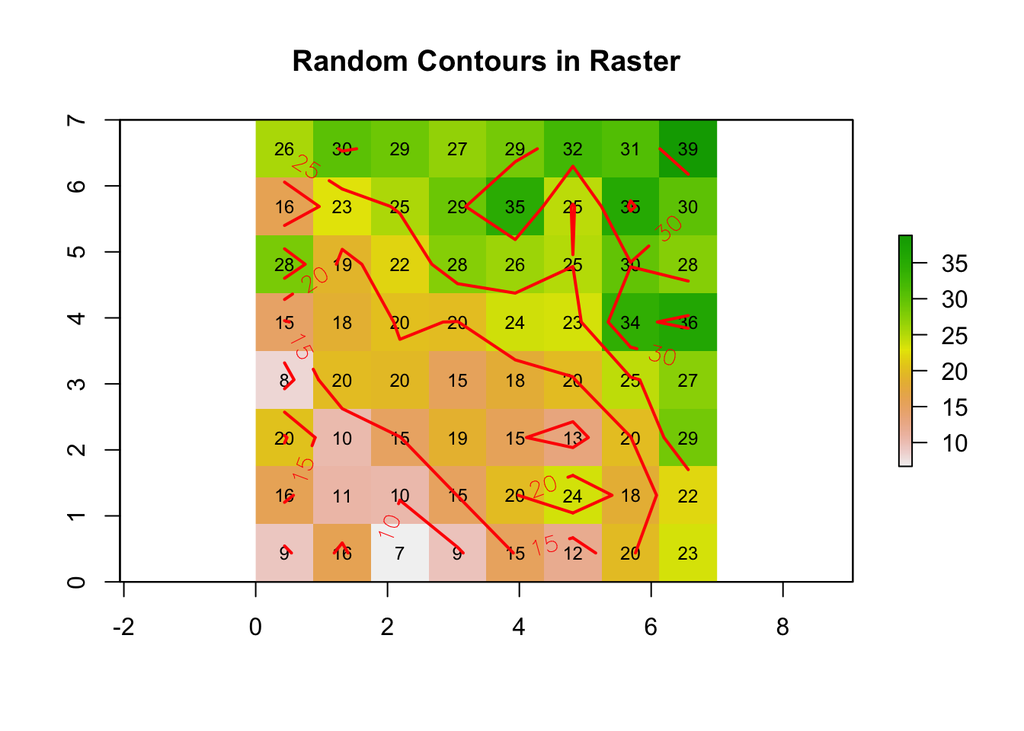

```r
#use the equation from the book
Z <- 2*X + 3*Y + R

#plot with contours
plot(Z, main = "Random Contours in Raster")
text(Z, cex = .75)
contour(Z, add = T, labcex = 1, lwd = 2, col = 'red')
```

Make a function

```r
#we can make a function of this to repeat the random pattern
f <- function() {
    n <- round(runif(ncell(r), min = 0, max = 9))
    m <- round(runif(ncell(r), min = 0, max = 9))
    s <- ifelse(n < 5, n + m, n - m)
    R <- setValues(r, s)
    Z <- 2*X + 3*Y + R
    return(Z)
}
```

Plot a pattern

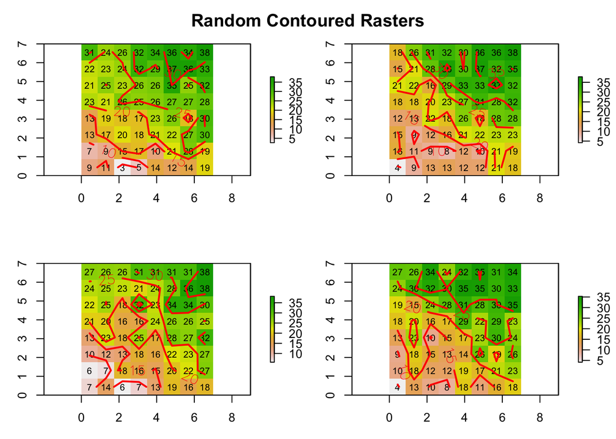

```r
#ensure replicability with set.seed
set.seed(2)
#set columns and rows and the margins (mai)
par(mfrow=c(2,2), mai=c(0.5,0.5,0.5,0.5))
#make 4 plots
for (i in 1:4) {
    pattern <- f()
    plot(pattern)
    text(pattern, cex=.75)
    contour(pattern, add=TRUE, labcex=1, lwd=2, col='red')
}
par(mfrow = c(1,1))
title(main = "Random Contoured Rasters", line = -1.5, outer = T)
```

## 2) Normal Distribution Plots

**Use the example of the CSR points maps to write a script that uses a normal distribution, rather than a random uniform distribution (also see box ‘different distributions’; on page 99 of OSU)**

Function for a uniform distribution

```r
#this creates a random plot using runif
csr <- function(n, r=99, plot=FALSE) {
    x <- runif(n, max=r)
    y <- runif(n, max=r)
    if (plot) {
        plot(x, y, xlim=c(0,r), ylim=c(0,r))
    }
}
```

Plots for a uniform distribution

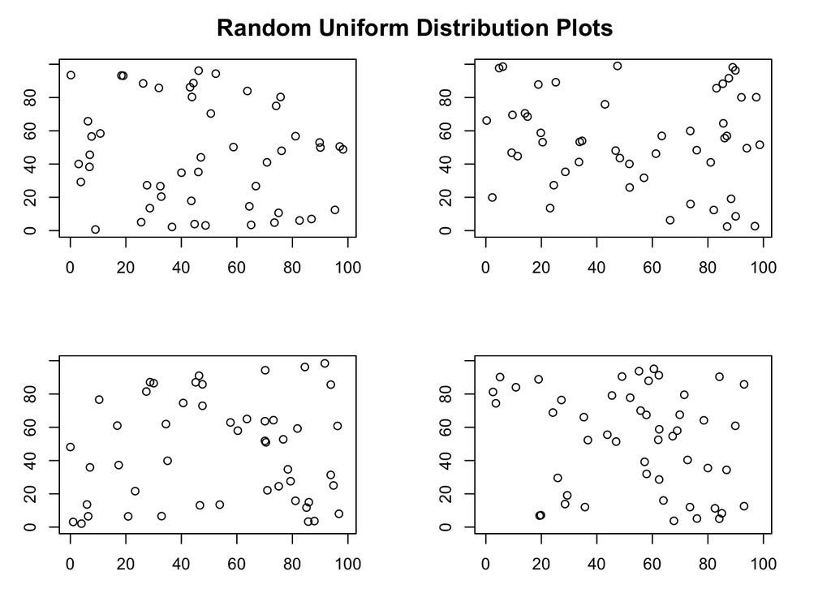

```r
#set.seed to start in the same random place
set.seed(20)

#set plotspace and margins
par(mfrow=c(2,2), mai=c(.5, .5, .5, .5))

#plot 4 of them
for (i in 1:4) {
    csr(50, plot=TRUE)
}
par(mfrow = c(1,1))
title(main = "Random Uniform Distribution Plots", line = -1.5, outer = T)
```

Function for a normal distribution

```r
#instead of runif, we'll use rnorm, note the different arguments from runif
csr.norm <- function(n, mn = 0, std = 2, plot=FALSE) {
    x <- rnorm(n, mean = mn, sd = std)
    y <- rnorm(n, mean = mn, sd = std)
    if (plot) {
        plot(x, y)
    }
}
```

Plots for the normal distribution

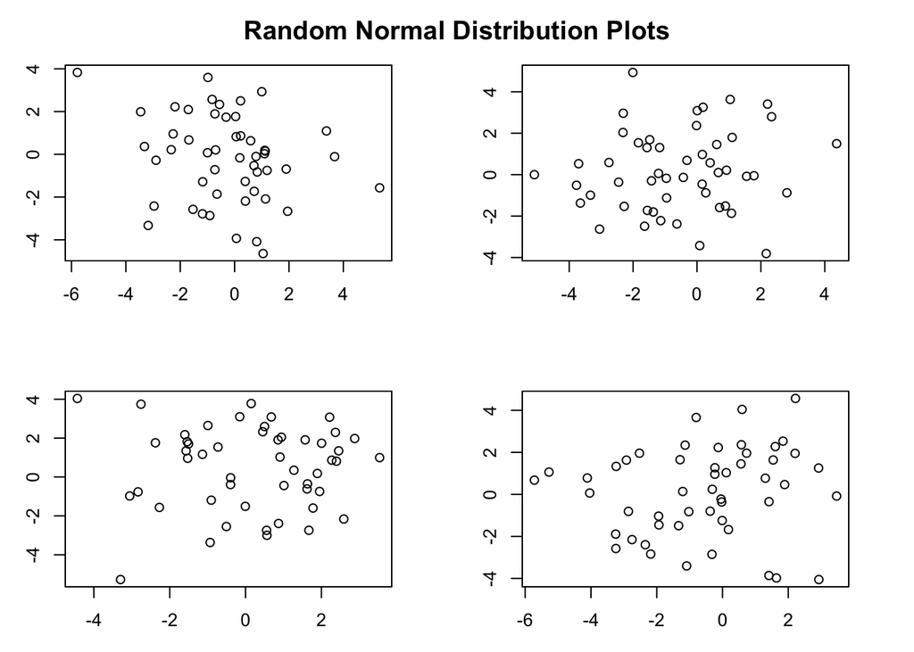

```r
#again plot, set seed
set.seed(50)

#set plotspace and margins
par(mfrow=c(2,2), mai=c(.5, .5, .5, .5))

#draw 4 plots
for (i in 1:4) {
    csr.norm(50, plot=TRUE)
}
par(mfrow = c(1,1))
title(main = "Random Normal Distribution Plots", line = -1.5, outer = T)
```

> The normal distributions appear to be more clustered together around the mean and less “random” as in the uniform distribution. The points are closer together and less evenly distributed. The closeness of points can be manipulated by changing the standard deviation.

## 3) Chessboard Rasters

**Do the generated chess boards look (positively or negatively) spatially autocorrelated?**

Generate a raster

```r
#make a raster
r <- raster(xmn=0, xmx=1, ymn=0, ymx=1, ncol=8, nrow=8)

#make polygons to map the edge lines
p <- rasterToPolygons(r)

#function chess to make a random chess board
chess <- function(label) {
    s <- sample(c(-1, 1), 64, replace=TRUE)
    values(r) <- s
    plot(r, col=c('black', 'white'),
         legend=FALSE, axes=FALSE, box=FALSE, main = label)
    plot(p, add=T, border='gray')
}
```

Plot some chessboards

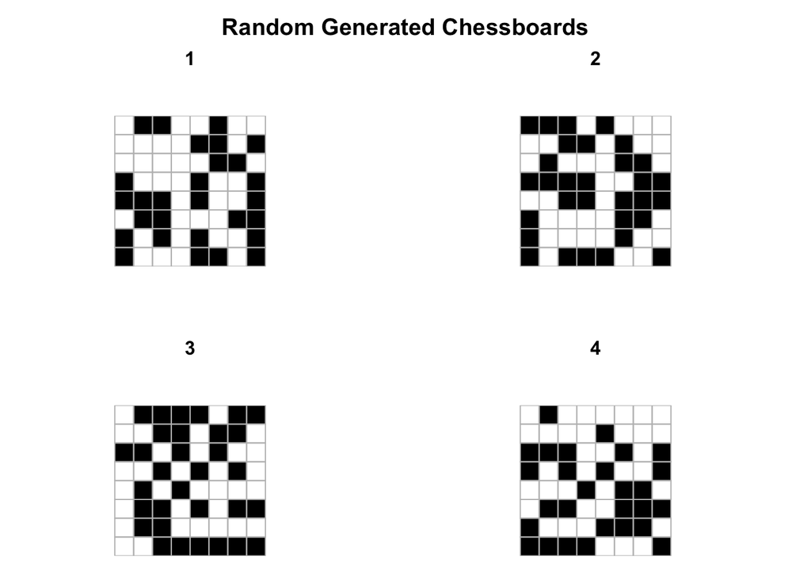

```r
#set random seed
set.seed(23)

#windows and margins
par(mfrow=c(2,2), mai=c(0.2, 0.3, 1, 0.2))

#for loop to draw 4 plots
for (i in 1:4) {
    chess(label = i)
}
par(mfrow = c(1,1))
title(main = "Random Generated Chessboards", line = -1.5, outer = T)
```

> Looking at the four generated chessboards, I would say that there is little to no spatial autocorrelation. I would guess that 3 & 4 might display some level of negative autocorrelation, but without doing further analyis, like using moran’s I, I can not say for sure.

## 4) Independent Generation

**How would you, conceptually, statistically test whether the real chessboard used in games is generated by an independent random process?**

> First, there is no distrubtion of chessboards that exist to test if a “real” chessboard is generated by an IRP. We would need to simulate a sample distribution like we did above, check to see if it is normally distributed, and then test the likelihood against a real chessboard.

> Because chessboards are perfectly negatively autocorrelated, we could test the likelyhood of perfect correlation against the null, random generation. We could calculate autocorrelation with the moran’s I statistic.

## 5) (bonus)

**Can you explain the odd distribution pattern of random line lengths inside a rectangle?**

> The function that creates the lines generates a point and finds a random angle for that point. The rectangle is bounded by axes of 0.6 and 0.8 (by default)

> Given the rectangle has a max line length of 1. There are only 4 points and 2 angles that produce a line length of 1, while line lengths >= 0.6 have many more possible point / angle combinations, resulting in an odd distribution pattern given in the example.